### Scripts

```r
source("Predictive performance assessment.R", local = knitr::knit_global())
source("Statistical analysis.R", local = knitr::knit_global())
```

### Dataset

```r
PB_predictors <- read.csv("Data/Phase behaviour and descriptors (25 pc step).csv")
```

The dataset was split into a training/testing (`TT_data`) and a validation dataset comprising 21 and 7 phase diagrams, respectively. Only the training/testing dataset was used in the selection of the random forest structure (*i.e.*, number of trees).

```r
TT_data <- filter(PB_predictors, Set == "Training")
```

A list of all phase behaviour predictor names was created and the phase behaviour variable was encoded as a factor.

```r
predictors_all <- colnames(TT_data[, 3:66][, -(4:6)])
TT_data$Phase.behaviour <- factor(as.character(TT_data$Phase.behaviour))
```

### Random forest - number of trees selection

#### Random forest algorithm

First, the function used to train and evaluated the random forest models was defined.

```r
run_random_forest <- function(training_testing_data, predictors, model_performance,
    model_name, model_number, trees) {

    # Training parameters
    PMsummary <- function(...) c(twoClassSummary(...), defaultSummary(...))
    trainCtrl <- trainControl(method = "cv", number = 10, summaryFunction = PMsummary,
        classProbs = TRUE)

    # Tuning
    mtryValues <- c(round(length(predictors)/5), round(length(predictors) * 2/5),
        round(length(predictors) * 3/5), round(length(predictors) * 4/5), length(predictors))

    # TT_data spliting
    trainIndex <- createDataPartition(training_testing_data$Phase.behaviour, p = 0.7,
        list = FALSE)
    training_data <- training_testing_data[trainIndex, ]
    testing_data <- training_testing_data[-trainIndex, ]

    # Model training
    rf_model <- train(training_data[, predictors], training_data$Phase.behaviour,
        method = "rf", ntree = trees, metric = "ROC", tuneGrid = data.frame(mtry = mtryValues),
        trControl = trainCtrl)


    # Model performance assessement
    model_performance <- model_performance_assessment(testing_data, predictors, model_performance,
        rf_model, model_name, model_number)

    return(model_performance)
}
```

#### Random forest models training and evaluation

Eight types random forest models (n=10) comprising a varying number of trees were trained and evaluated.

```r
trees_list <- c(1, 5, 10, 50, 100, 500, 1000, 5000)
```

```r
for (i in 1:length(trees_list)) {
    for (j in 1:10) {
        model_number = (i - 1) * 10 + j
        model_name = paste("RF", trees_list[i])
        model_performance_trees <- run_random_forest(TT_data, predictors_all, model_performance_trees,
            model_name, model_number, trees_list[i])
    }
}
```

#### Random forest models performance comparison

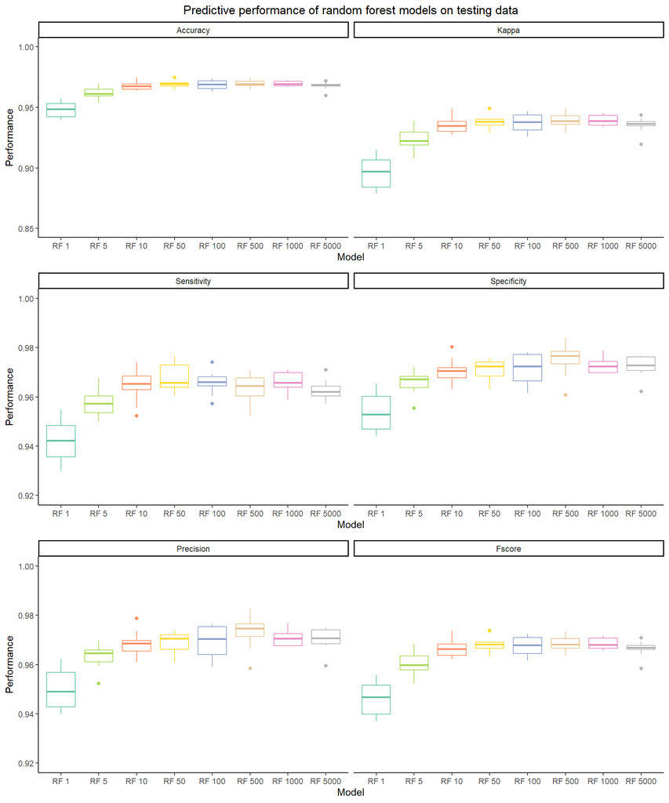

The results suggest that the number of trees comprising the random forests affects the models' predictive performance. Specifically, models incorporating few trees (*i.e.*, less than 50) generally exhibit a comparatively lower prediction performance on the training data and so does the model employing the most trees (*i.e.*, 5000), likely due to data overfitting. Random forests comprising between 50 and 1000 trees appear to perform equally well.

### Number of trees selection using AUC metric

To select the best random forest model structure for the phase behaviour classification problem, the area under the receiver operating characteristic (ROC) curve (AUC) for the predictions of the eigth investigated model structures on the testing data (*i.e.*, 30% of `TT_data`, which was not used for training) was compared.

**Visual comparison**

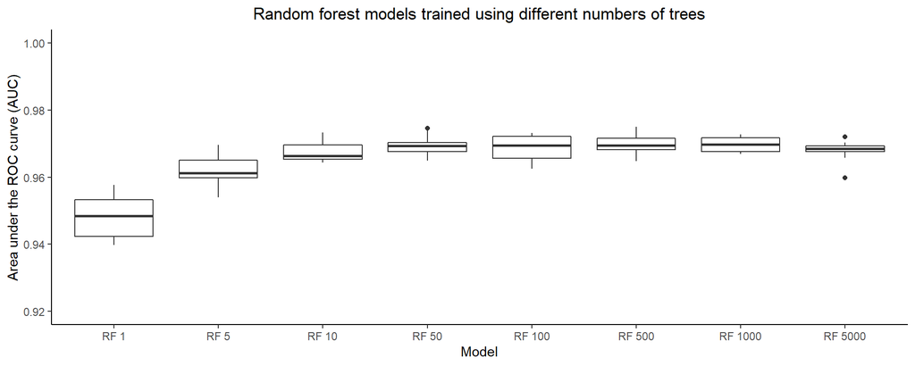

**Statistical comparison**

```
## Data normally distributed.
## Variance comparable across groups.
## One-way ANOVA test: There are significant differences between the groups.
```

```
##   Tukey multiple comparisons of means
##     95% family-wise confidence level
##
## Fit: aov(formula = dep_variable ~ ind_variable, data = data)
##
## $ind_variable
##                          diff           lwr           upr     p adj
## RF 10-RF 1       0.0193035385  0.0138255222  0.0247815548 0.0000000
## RF 100-RF 1      0.0206165515  0.0151385352  0.0260945678 0.0000000
## RF 1000-RF 1     0.0214573944  0.0159793781  0.0269354107 0.0000000
## RF 5-RF 1        0.0138573694  0.0083793531  0.0193353857 0.0000000
## RF 50-RF 1       0.0213487506  0.0158707343  0.0268267669 0.0000000
## RF 500-RF 1      0.0217539246  0.0162759083  0.0272319409 0.0000000
## RF 5000-RF 1     0.0196701353  0.0141921190  0.0251481516 0.0000000
## RF 100-RF 10     0.0013130130 -0.0041650033  0.0067910293 0.9950825
## RF 1000-RF 10    0.0021538559 -0.0033241604  0.0076318722 0.9210114
## RF 5-RF 10      -0.0054461691 -0.0109241854  0.0000318472 0.0524432
## RF 50-RF 10      0.0020452121 -0.0034328042  0.0075232284 0.9390082
## RF 500-RF 10     0.0024503861 -0.0030276302  0.0079284024 0.8559675
## RF 5000-RF 10    0.0003665968 -0.0051114195  0.0058446131 0.9999990
## RF 1000-RF 100   0.0008408429 -0.0046371734  0.0063188592 0.9997198
## RF 5-RF 100     -0.0067591821 -0.0122371984 -0.0012811658 0.0058550
## RF 50-RF 100     0.0007321991 -0.0047458172  0.0062102154 0.9998889
## RF 500-RF 100    0.0011373731 -0.0043406432  0.0066153894 0.9979975
## RF 5000-RF 100  -0.0009464162 -0.0064244325  0.0045316001 0.9993887
## RF 5-RF 1000    -0.0076000250 -0.0130780413 -0.0021220087 0.0011743
## RF 50-RF 1000   -0.0001086438 -0.0055866601  0.0053693725 1.0000000
## RF 500-RF 1000   0.0002965302 -0.0051814861  0.0057745465 0.9999998
## RF 5000-RF 1000 -0.0017872591 -0.0072652754  0.0036907572 0.9701333
## RF 50-RF 5       0.0074913812  0.0020133649  0.0129693975 0.0014559
## RF 500-RF 5      0.0078965552  0.0024185389  0.0133745715 0.0006465
## RF 5000-RF 5     0.0058127659  0.0003347496  0.0112907822 0.0297482
## RF 500-RF 50     0.0004051740 -0.0050728423  0.0058831903 0.9999981
## RF 5000-RF 50   -0.0016786153 -0.0071566316  0.0037994010 0.9789467
## RF 5000-RF 500  -0.0020837893 -0.0075618056  0.0033942270 0.9329686
```

**The four model structures employing 50, 100, 500 or 1000 decision trees all performed equally well. The average AUC for these model types (n = 10) was between 0.9688 ± 0.004 and 0.9699 ± 0.003 and the differences between them were not statistically significant with the corresponding p-values ranging between 0.998 and 1.**  
**Conversely, the two models comprising the smallest number of trees (*i.e.*, 1 and 5) both performed statistically significantly worse than all models comprising 50 to 1000 trees (p-values between 0 and 0.006).**  
**Lastly, the models comprising 10 and 5000 decision trees had an average AUC of 0.9675 ± 0.003 and 0.9679 ± 0.003, respectively, suggesting their prediction performance on the training data is sligtly worse than the four models employing 50 to 1000 trees, however, not statistically significantly so (p-values between 0.856 and 0.999).**  
**To reduce the computational demand of the following feature selection steps, while not decreasing the predictive performance of the algorithm, the random forest structure comprising 50 decision trees was selected to carry forward.**